# Lab 1 - Introduction-SampleOutput

## Task 2 - Plotting

Plotting is a key activity in Data Science. Matplotlib is a widely used plotting library in python. Here is the documentation: https://matplotlib.org/api/pyplot_api.html. We're going to start by going through the official `pyplot` tutorial. Please go through the tutorial and familiarize yourself with the basics of `pyplot`. This should take roughly 25 minutes.

```python
# Matplotlib is a Python 2D plotting library
import matplotlib.pyplot as plt

# %matplotlib inline is a magic command in Python that visualizes and stores any plots you draw or any plots
# we provide directly in the notebook.
%matplotlib inline
```

Now that you're familiar with the basics of `pyplot`, let's practice with some `pyplot` questions.

### Question 2.1

Let's visualize the function $f(t) = 3\sin(2\pi t)$. Set the x limit of all figures to $[0, \pi]$ and the y limit to $[-10, 10]$. Plot the sine function using `plt.plot` with 30 red plus signs. Additionally, make sure the x ticks are labeled $[0, \frac{\pi}{2}, \pi]$, and that your axes are labeled as well.

Your plot should look like the following:

[figure not shown]

Hint 1: You can set axis bounds with `plt.axis`.

Hint 2: You can set xticks and labels with `plt.xticks`.

Hint 3: Make sure you add `plt.xlabel`, `plt.ylabel`, `plt.title`

[figure not shown]

```python
### BEGIN SOLUTION

### END SOLUTION
```

### Question 2.2

Set the x limit of all figures to $[0, \pi]$ and the y limit to $[-10, 10]$. The figure size should be 8 by 8. Make sure to label your x and y axes with the appropriate value of $f$ or $a$. Additionally, make sure the x ticks are labeled $[0, \frac{\pi}{2}, \pi]$. Your overall plot should look something like this:

[figure not shown]

Hint 1: Modularize your code and use loops.

Hint 2: Are your plots too close together such that the labels are overlapping with other plots? Look at the [`plt.subplots_adjust`](https://matplotlib.org/api/_as_gen/matplotlib.pyplot.subplots_adjust.html) function.

Hint 3: Having trouble setting the x-axis ticks and ticklabels? Look at the [`plt.xticks`](https://matplotlib.org/api/_as_gen/matplotlib.pyplot.xticks.html) function.

Hint 4: You can add title to overall plot with `plt.suptitle`.

[figure not shown]

```python
### BEGIN SOLUTION


### END SOLUTION
```

## Question 2.3 3D Plotting

### Activity 1

Observe the values of (x,y) that minimizes the function f(x,y)

### Activity 2

Change the function to $$f(x,y) = xy $$ and re-plot. Estimate the values (x,y) that minimizes f(x,y)?

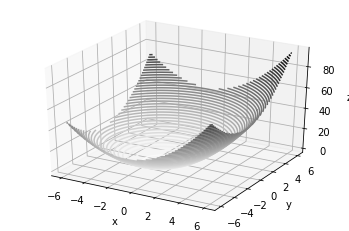

```python
from mpl_toolkits import mplot3d
%matplotlib inline
import numpy as np
import matplotlib.pyplot as plt

def f(x, y):
    return (x**2 + y**2 + 2*x + 2*y)

x = np.linspace(-6, 6, 30)
y = np.linspace(-6, 6, 30)

X, Y = np.meshgrid(x, y)
Z = f(X, Y)

fig = plt.figure()
ax = plt.axes(projection='3d')
ax.contour3D(X, Y, Z, 50, cmap='binary')
ax.set_xlabel('x')
ax.set_ylabel('y')
ax.set_zlabel('z');
```

## Task 3 - Reading Documentation

We should also familiarize ourselves with looking up documentation and learning how to read it. Below is a section of code that plots a basic wireframe. Replace each `# Your answer here` with a description of what the line above does, what the arguments being passed in are, and how the arguments are used in the function. For example youe answer may look like,

`np.arange(2, 5, 0.2)`

`# This returns an array of numbers from 2 to 5 with an interval size of 0.2`

Hint: The `Shift` + `Tab` (to see what a function does) tip from earlier in the notebook may help here.

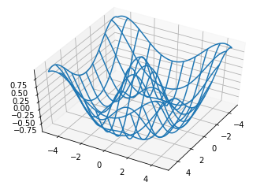

```python
from mpl_toolkits.mplot3d import axes3d

u = np.linspace(1.5*np.pi, -1.5*np.pi, 100)
# Your answer here
[x,y] = np.meshgrid(u, u)
# Your answer here
squared = np.sqrt(x.flatten()**2 + y.flatten()**2)
z = np.cos(squared)
# Your answer here
z = z.reshape(x.shape)
# Your answer here

fig = plt.figure()
ax = fig.add_subplot(111, projection='3d')
# Your answer here
ax.plot_wireframe(x, y, z, rstride=10, cstride=10)
# Your answer here
ax.view_init(elev=50., azim=30)
# Your answer here
plt.savefig("figure1.png")
```

## Task 4 - Feedback

What do you expect to learn from this course? Tell us what you think by creating a Markdown cell below this cell. Be sure to save your file (ctril-S) regularly.

## Submission Instructions

**File Name:** Please name the file as your_netID_lab1.ipynb (eg: adg133_lab1.ipynb)  
**Submit To:** Canvas → Assignments → Lab1  
**Warning:** Failure to follow directions may result in loss points.

Thanks to Josh Hug and Berkeley Data Science Group for some ideas used in this notebook.